# US Open 2019 Analysis

### Top Individual Match Performance

These sections focus on individual matches for all wrestlers who competed in the event.  
Analysis will still favor the KPMs (Key Performance Metrics: APM and NPF).

```python
print('None of the 2 matches with an APM > 31 resulted in a Fall...')
display(df[df['APM'] > df['APM'].mean() * 3]\
        [['Result', 'MatchID', 'Focus', 'Opponent',
          'NPF', 'APM', 'Duration', 'FocusPoints', 'OppPoints']])
```

[output not shown]

```python
print('11 matches with a WinF result and 2.0 NPF.')
display(df[(df['NPF'] == 2.0) & (df['Result'] == 'WinF')]\
        [['Result', 'MatchID', 'Focus', 'Opponent',
          'NPF', 'APM', 'Duration', 'FocusPoints', 'OppPoints']].sort_values(['APM'], ascending=False))
```

[output not shown]

From these two lists of matches it is clear that there are many great performances to choose from. The Perkin WinF over Kindig is tempting as it has the highest APM of any match with a 2.0 NPF and WinF result. However, the Cole WinF over Garcia seems a stronger contender as it has roughly the same APM and was finished in half the time (55 seconds versus 96 seconds).

Ultimately I will drop both of these options in favor of the 40.0 APM Graff WinD over Brewer. This match was a 38 point storm that resulted in the highest APM of the tournament despite a relateively even NPF (1.15 for Graff).

## Weight Class Analysis

```python
base_cols = ['BinaryResult',
             'HIa', 'HIc2', 'HIc4', 'HOa', 'HOc2', 'HOc4', 'Da', 'Dc2', 'Dc4',
             'LSa', 'LSc2', 'LSc4', 'GBa', 'GBc2', 'Ta', 'Tc2', 'Tc4',
             'Exposure', 'Gut', 'LegLace',  'Turn', 'Pushout', 'Violation', 'Passive',
             'oHIa', 'oHIc2', 'oHIc4', 'oHOa', 'oHOc2', 'oHOc4', 'oDa', 'oDc2', 'oDc4',
             'oLSa', 'oLSc2', 'oLSc4', 'oGBa', 'oGBc2', 'oTa', 'oTc2', 'oTc4',
             'oExposure', 'oGut', 'oLegLace',  'oTurn', 'oPushout', 'oViolation', 'oPassive',
            ]
```

### 57 kilos <sup>69 matches</sup>

#### Placements

1. Daton Fix
2. Thomas Gilman
3. Zane Richards
4. Vitali Arujau
5. Darian Cruz
6. Nathan Tomasello
7. Frank Perrelli
8. Zach Sanders

```python
kgs57 = df[df['Weight'] == 57]
```

[output not shown]

#### Distributions

This section focuses on illustrating the distribution of Results and ShotTypes for this event.

Techs are the most common result followed by Decisions and then Falls as is typical with a Freestyle event.

```python
print('Distributions of match results.')
sns.catplot("Result", data=kgs57[kgs57['MatchID'].map(len) == 4], kind="count")
plt.show()

# somehow order so can use palatte for win/loss
```

[output not shown]

```
Distributions of match results.
```

[output not shown]

GBa will almost exclusively be #1 on this list due to the large variety of conditions under which it is recorded. More interesting is the high GBrate and even higher HIrate at this weight. Other ShotTypes follow their corresponding attempts patterns.

```python
sns.barplot(x='index', y='Shots',
            data=kgs57.sum()[['HIa', 'HOa', 'Da', 'LSa', 'GBa', 'Ta']]\
            .rename('Shots').reset_index())
plt.show()
sns.barplot(x='index', y='ConversionRate',
            data=kgs57.mean()[['HIrate', 'HOrate', 'Drate', 'LSrate', 'GBrate', 'Trate']]\
            .rename('ConversionRate').reset_index())
plt.show()
```

[output not shown]

[output not shown]

#### Trends

This section focuses on identifying key metrics for success at this weight (at this event).  
The analysis does not take into consideration the value of more powerful results. In otherwords, correlations are done only on binary win/loss results and **not** on the degree of the result. So a strong correlation indicates a higher relationship with winning but **not** the degree of winning.

Remember correlations range from -1 to +1 the former representating a strong relationship with a negative outcome (in this case losing the match) and the latter representation a strong relationship with a positive outcome (i.e. winning a match). Correlations closer to 0 represent weak relationships and correlations around 0.5 represent moderate relationships.

```
Top actions for 57kgs at this event.
```

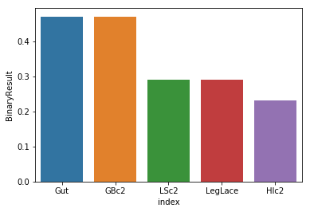

```python
print('Top actions for 57kgs at this event.')
sns.barplot(x='index', y='BinaryResult',
    data=kgs57[base_cols].corr().round(2).sort_values(by=['BinaryResult'], ascending=False)['BinaryResult'][1:6].reset_index())
plt.show()
```

### 61 kilos <sup>61 matches</sup>

#### Placements

1. Cody Brewer
2. Nico Megaludis
3. Joey Palmer
4. Tyler Graff
5. Cory Clark
6. Anthony Ramos
7. Earl Hall
8. Beau Bartlett

```python
kgs61 = df[df['Weight'] == 61]
```

#### Distributions

This section focuses on illustrating the distribution of Results and ShotTypes for this event.

Techs are the most common result followed by Decisions and then Falls as is typical with a Freestyle event.

```
Distributions of match results.
```

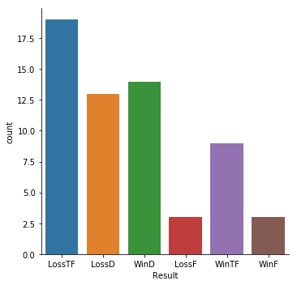

```python
print('Distributions of match results.')
sns.catplot("Result", data=kgs61[kgs61['MatchID'].map(len) == 4], kind="count")
plt.show()

# somehow order so can use palatte for win/loss
```

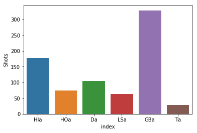

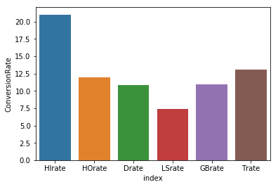

```python
sns.barplot(x='index', y='Shots',
            data=kgs61.sum()[['HIa', 'HOa', 'Da', 'LSa', 'GBa', 'Ta']]\
            .rename('Shots').reset_index())
plt.show()
sns.barplot(x='index', y='ConversionRate',
            data=kgs61.mean()[['HIrate', 'HOrate', 'Drate', 'LSrate', 'GBrate', 'Trate']]\
            .rename('ConversionRate').reset_index())
plt.show()
```

#### Trends

This section focuses on identifying key metrics for success at this weight (at this event).  
The analysis does not take into consideration the value of more powerful results. In otherwords, correlations are done only on binary win/loss results and **not** on the degree of the result. So a strong correlation indicates a higher relationship with winning but **not** the degree of winning.

Remember correlations range from -1 to +1 the former representating a strong relationship with a negative outcome (in this case losing the match) and the latter representation a strong relationship with a positive outcome (i.e. winning a match). Correlations closer to 0 represent weak relationships and correlations around 0.5 represent moderate relationships.

```
Top actions for 61kgs at this event.
```

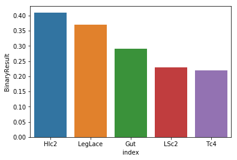

```python
print('Top actions for 61kgs at this event.')
sns.barplot(x='index', y='BinaryResult',
    data=kgs61[base_cols].corr().round(2).sort_values(by=['BinaryResult'], ascending=False)['BinaryResult'][1:6].reset_index())
plt.show()
```

### 65 kilos <sup>92 matches</sup>

#### Placements

1. Yianni Diakomihalis
2. Zain Retherford
3. Jason Ness
4. Frank Molinaro
5. Jaydin Eirman
6. Jordan Oliver
7. Kanen Storr
8. Bernard Futrell

```python
kgs65 = df[df['Weight'] == 65]
```

#### Distributions

This section focuses on illustrating the distribution of Results and ShotTypes for this event.

Techs are the most common result followed by Decisions and then Falls as is typical with a Freestyle event.

```
Distributions of match results.
```

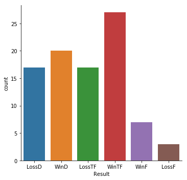

```python
print('Distributions of match results.')
sns.catplot("Result", data=kgs65[kgs65['MatchID'].map(len) == 4], kind="count")
plt.show()

# somehow order so can use palatte for win/loss
```

GBa will almost exclusively be #1 on this list due to the large variety of conditions under which it is recorded. More interesting is the high GBrate and even higher HIrate at this weight. Other ShotTypes follow their corresponding attempts patterns.

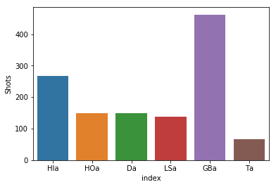

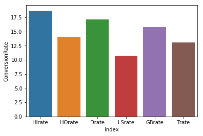

```python
sns.barplot(x='index', y='Shots',
            data=kgs65.sum()[['HIa', 'HOa', 'Da', 'LSa', 'GBa', 'Ta']]\
            .rename('Shots').reset_index())
plt.show()
sns.barplot(x='index', y='ConversionRate',
            data=kgs65.mean()[['HIrate', 'HOrate', 'Drate', 'LSrate', 'GBrate', 'Trate']]\
            .rename('ConversionRate').reset_index())
plt.show()
```

#### Trends

This section focuses on identifying key metrics for success at this weight (at this event).  
The analysis does not take into consideration the value of more powerful results. In otherwords, correlations are done only on binary win/loss results and **not** on the degree of the result. So a strong correlation indicates a higher relationship with winning but **not** the degree of winning.

Remember correlations range from -1 to +1 the former representating a strong relationship with a negative outcome (in this case losing the match) and the latter representation a strong relationship with a positive outcome (i.e. winning a match). Correlations closer to 0 represent weak relationships and correlations around 0.5 represent moderate relationships.

```
Top actions for 65kgs at this event.
```

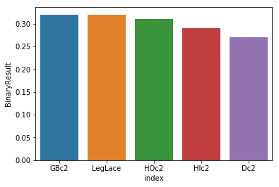

```python
print('Top actions for 65kgs at this event.')
sns.barplot(x='index', y='BinaryResult',
    data=kgs65[base_cols].corr().round(2).sort_values(by=['BinaryResult'], ascending=False)['BinaryResult'][1:6].reset_index())
plt.show()
```

### 70 kilos <sup>96 matches</sup>

#### Placements

1. Ryan Deakin
2. James Green
3. Jason Nolf
4. Alec Pantaleo
5. Brandon Sorensen
6. Nazar Kulchytskyy
7. Jason Chamberlain
8. Anthony Collica

```python
kgs70 = df[df['Weight'] == 70]
```

#### Distributions

This section focuses on illustrating the distribution of Results and ShotTypes for this event.

Techs are the most common result followed by Decisions and then Falls as is typical with a Freestyle event.

```
Distributions of match results.
```

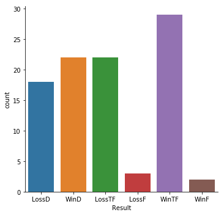

```python
print('Distributions of match results.')
sns.catplot("Result", data=kgs70[kgs70['MatchID'].map(len) == 4], kind="count")
plt.show()

# somehow order so can use palatte for win/loss
```

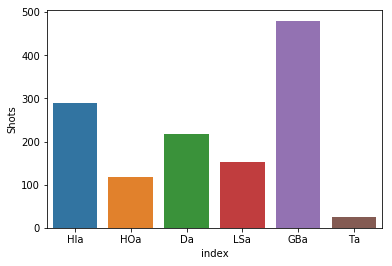

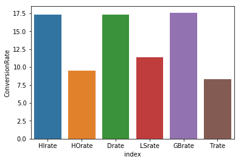

```python
sns.barplot(x='index', y='Shots',
            data=kgs70.sum()[['HIa', 'HOa', 'Da', 'LSa', 'GBa', 'Ta']]\
            .rename('Shots').reset_index())
plt.show()
sns.barplot(x='index', y='ConversionRate',
            data=kgs70.mean()[['HIrate', 'HOrate', 'Drate', 'LSrate', 'GBrate', 'Trate']]\
            .rename('ConversionRate').reset_index())
plt.show()
```

#### Trends

This section focuses on identifying key metrics for success at this weight (at this event).  
The analysis does not take into consideration the value of more powerful results. In otherwords, correlations are done only on binary win/loss results and **not** on the degree of the result. So a strong correlation indicates a higher relationship with winning but **not** the degree of winning.

Remember correlations range from -1 to +1 the former representating a strong relationship with a negative outcome (in this case losing the match) and the latter representation a strong relationship with a positive outcome (i.e. winning a match). Correlations closer to 0 represent weak relationships and correlations around 0.5 represent moderate relationships.

```
Top actions for 70kgs at this event.
```

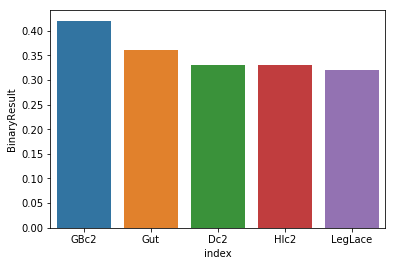

```python
print('Top actions for 70kgs at this event.')
sns.barplot(x='index', y='BinaryResult',
    data=kgs70[base_cols].corr().round(2).sort_values(by=['BinaryResult'], ascending=False)['BinaryResult'][1:6].reset_index())
plt.show()
```

#### Placements

```python
kgs57 = df[df['Weight'] == 57]
```

#### Distributions

This section focuses on illustrating the distribution of Results and ShotTypes for this event.

Techs are the most common result followed by Decisions and then Falls as is typical with a Freestyle event.

```python
print('Distributions of match results.')
sns.catplot("Result", data=kgs57[kgs57['MatchID'].map(len) == 4], kind="count")
g.set_xticklabels(rotation=30)
plt.show()

# somehow order so can use palatte for win/loss
```

[output not shown]

```
Distributions of match results.
```

GBa will almost exclusively be #1 on this list due to the large variety of conditions under which it is recorded. More interesting is the high GBrate and even higher HIrate at this weight. Other ShotTypes follow their corresponding attempts patterns.

```python
sns.barplot(x='index', y='Shots',
            data=kgs57.sum()[['HIa', 'HOa', 'Da', 'LSa', 'GBa', 'Ta']]\
            .rename('Shots').reset_index())
plt.show()
sns.barplot(x='index', y='ConversionRate',
            data=kgs57.mean()[['HIrate', 'HOrate', 'Drate', 'LSrate', 'GBrate', 'Trate']]\
            .rename('ConversionRate').reset_index())
plt.show()
```

[output not shown]

#### Trends

This section focuses on identifying key metrics for success at this weight (at this event).  
The analysis does not take into consideration the value of more powerful results. In otherwords, correlations are done only on binary win/loss results and **not** on the degree of the result. So a strong correlation indicates a higher relationship with winning but **not** the degree of winning.

Remember correlations range from -1 to +1 the former representating a strong relationship with a negative outcome (in this case losing the match) and the latter representation a strong relationship with a positive outcome (i.e. winning a match). Correlations closer to 0 represent weak relationships and correlations around 0.5 represent moderate relationships.

```python
print('Top actions for 57kgs at this event.')
sns.barplot(x='index', y='BinaryResult',
    data=kgs57[base_cols].corr().round(2).sort_values(by=['BinaryResult'], ascending=False)['BinaryResult'][1:6].reset_index())
plt.show()
```

[output not shown]

```
Top actions for 57kgs at this event.
```

#### Placements

```python
kgs57 = df[df['Weight'] == 57]
```

#### Distributions

This section focuses on illustrating the distribution of Results and ShotTypes for this event.

Techs are the most common result followed by Decisions and then Falls as is typical with a Freestyle event.

```python
print('Distributions of match results.')
sns.catplot("Result", data=kgs57[kgs57['MatchID'].map(len) == 4], kind="count")
g.set_xticklabels(rotation=30)
plt.show()

# somehow order so can use palatte for win/loss
```

[output not shown]

```
Distributions of match results.
```

GBa will almost exclusively be #1 on this list due to the large variety of conditions under which it is recorded. More interesting is the high GBrate and even higher HIrate at this weight. Other ShotTypes follow their corresponding attempts patterns.

```python
sns.barplot(x='index', y='Shots',
            data=kgs57.sum()[['HIa', 'HOa', 'Da', 'LSa', 'GBa', 'Ta']]\
            .rename('Shots').reset_index())
plt.show()
sns.barplot(x='index', y='ConversionRate',
            data=kgs57.mean()[['HIrate', 'HOrate', 'Drate', 'LSrate', 'GBrate', 'Trate']]\
            .rename('ConversionRate').reset_index())
plt.show()
```

[output not shown]

#### Trends

This section focuses on identifying key metrics for success at this weight (at this event).  
The analysis does not take into consideration the value of more powerful results. In otherwords, correlations are done only on binary win/loss results and **not** on the degree of the result. So a strong correlation indicates a higher relationship with winning but **not** the degree of winning.

Remember correlations range from -1 to +1 the former representating a strong relationship with a negative outcome (in this case losing the match) and the latter representation a strong relationship with a positive outcome (i.e. winning a match). Correlations closer to 0 represent weak relationships and correlations around 0.5 represent moderate relationships.

```python
print('Top actions for 57kgs at this event.')
sns.barplot(x='index', y='BinaryResult',
    data=kgs57[base_cols].corr().round(2).sort_values(by=['BinaryResult'], ascending=False)['BinaryResult'][1:6].reset_index())
plt.show()
```

[output not shown]

```
Top actions for 57kgs at this event.
```

#### Placements

```python
kgs57 = df[df['Weight'] == 57]
```

#### Distributions

This section focuses on illustrating the distribution of Results and ShotTypes for this event.

Techs are the most common result followed by Decisions and then Falls as is typical with a Freestyle event.

```python
print('Distributions of match results.')
sns.catplot("Result", data=kgs57[kgs57['MatchID'].map(len) == 4], kind="count")
g.set_xticklabels(rotation=30)
plt.show()

# somehow order so can use palatte for win/loss
```

[output not shown]

```
Distributions of match results.
```

GBa will almost exclusively be #1 on this list due to the large variety of conditions under which it is recorded. More interesting is the high GBrate and even higher HIrate at this weight. Other ShotTypes follow their corresponding attempts patterns.

```python
sns.barplot(x='index', y='Shots',
            data=kgs57.sum()[['HIa', 'HOa', 'Da', 'LSa', 'GBa', 'Ta']]\
            .rename('Shots').reset_index())
plt.show()
sns.barplot(x='index', y='ConversionRate',
            data=kgs57.mean()[['HIrate', 'HOrate', 'Drate', 'LSrate', 'GBrate', 'Trate']]\
            .rename('ConversionRate').reset_index())
plt.show()
```

[output not shown]

#### Trends

This section focuses on identifying key metrics for success at this weight (at this event).  
The analysis does not take into consideration the value of more powerful results. In otherwords, correlations are done only on binary win/loss results and **not** on the degree of the result. So a strong correlation indicates a higher relationship with winning but **not** the degree of winning.

Remember correlations range from -1 to +1 the former representating a strong relationship with a negative outcome (in this case losing the match) and the latter representation a strong relationship with a positive outcome (i.e. winning a match). Correlations closer to 0 represent weak relationships and correlations around 0.5 represent moderate relationships.

```python
print('Top actions for 57kgs at this event.')
sns.barplot(x='index', y='BinaryResult',
    data=kgs57[base_cols].corr().round(2).sort_values(by=['BinaryResult'], ascending=False)['BinaryResult'][1:6].reset_index())
plt.show()
```

[output not shown]

```
Top actions for 57kgs at this event.
```

#### Placements

```python
kgs57 = df[df['Weight'] == 57]
```

#### Distributions

This section focuses on illustrating the distribution of Results and ShotTypes for this event.

Techs are the most common result followed by Decisions and then Falls as is typical with a Freestyle event.

```python
print('Distributions of match results.')
sns.catplot("Result", data=kgs57[kgs57['MatchID'].map(len) == 4], kind="count")
g.set_xticklabels(rotation=30)
plt.show()

# somehow order so can use palatte for win/loss
```

[output not shown]

```
Distributions of match results.
```

GBa will almost exclusively be #1 on this list due to the large variety of conditions under which it is recorded. More interesting is the high GBrate and even higher HIrate at this weight. Other ShotTypes follow their corresponding attempts patterns.

```python
sns.barplot(x='index', y='Shots',
            data=kgs57.sum()[['HIa', 'HOa', 'Da', 'LSa', 'GBa', 'Ta']]\
            .rename('Shots').reset_index())
plt.show()
sns.barplot(x='index', y='ConversionRate',
            data=kgs57.mean()[['HIrate', 'HOrate', 'Drate', 'LSrate', 'GBrate', 'Trate']]\
            .rename('ConversionRate').reset_index())
plt.show()
```

[output not shown]

#### Trends

This section focuses on identifying key metrics for success at this weight (at this event).  
The analysis does not take into consideration the value of more powerful results. In otherwords, correlations are done only on binary win/loss results and **not** on the degree of the result. So a strong correlation indicates a higher relationship with winning but **not** the degree of winning.

Remember correlations range from -1 to +1 the former representating a strong relationship with a negative outcome (in this case losing the match) and the latter representation a strong relationship with a positive outcome (i.e. winning a match). Correlations closer to 0 represent weak relationships and correlations around 0.5 represent moderate relationships.

```python
print('Top actions for 57kgs at this event.')
sns.barplot(x='index', y='BinaryResult',
    data=kgs57[base_cols].corr().round(2).sort_values(by=['BinaryResult'], ascending=False)['BinaryResult'][1:6].reset_index())
plt.show()
```

[output not shown]

```
Top actions for 57kgs at this event.
```

#### Placements

```python
kgs57 = df[df['Weight'] == 57]
```

#### Distributions

This section focuses on illustrating the distribution of Results and ShotTypes for this event.

Techs are the most common result followed by Decisions and then Falls as is typical with a Freestyle event.

```python
print('Distributions of match results.')
sns.catplot("Result", data=kgs57[kgs57['MatchID'].map(len) == 4], kind="count")
g.set_xticklabels(rotation=30)
plt.show()

# somehow order so can use palatte for win/loss
```

[output not shown]

```
Distributions of match results.
```

GBa will almost exclusively be #1 on this list due to the large variety of conditions under which it is recorded. More interesting is the high GBrate and even higher HIrate at this weight. Other ShotTypes follow their corresponding attempts patterns.

```python
sns.barplot(x='index', y='Shots',
            data=kgs57.sum()[['HIa', 'HOa', 'Da', 'LSa', 'GBa', 'Ta']]\
            .rename('Shots').reset_index())
plt.show()
sns.barplot(x='index', y='ConversionRate',
            data=kgs57.mean()[['HIrate', 'HOrate', 'Drate', 'LSrate', 'GBrate', 'Trate']]\
            .rename('ConversionRate').reset_index())
plt.show()
```

[output not shown]

#### Trends

This section focuses on identifying key metrics for success at this weight (at this event).  
The analysis does not take into consideration the value of more powerful results. In otherwords, correlations are done only on binary win/loss results and **not** on the degree of the result. So a strong correlation indicates a higher relationship with winning but **not** the degree of winning.

Remember correlations range from -1 to +1 the former representating a strong relationship with a negative outcome (in this case losing the match) and the latter representation a strong relationship with a positive outcome (i.e. winning a match). Correlations closer to 0 represent weak relationships and correlations around 0.5 represent moderate relationships.

```python
print('Top actions for 57kgs at this event.')
sns.barplot(x='index', y='BinaryResult',
    data=kgs57[base_cols].corr().round(2).sort_values(by=['BinaryResult'], ascending=False)['BinaryResult'][1:6].reset_index())
plt.show()
```

[output not shown]

```
Top actions for 57kgs at this event.
```

#### Placements

```python
kgs57 = df[df['Weight'] == 57]
```

#### Distributions

This section focuses on illustrating the distribution of Results and ShotTypes for this event.

Techs are the most common result followed by Decisions and then Falls as is typical with a Freestyle event.

```python
print('Distributions of match results.')
sns.catplot("Result", data=kgs57[kgs57['MatchID'].map(len) == 4], kind="count")
g.set_xticklabels(rotation=30)
plt.show()

# somehow order so can use palatte for win/loss
```

[output not shown]

```
Distributions of match results.
```

GBa will almost exclusively be #1 on this list due to the large variety of conditions under which it is recorded. More interesting is the high GBrate and even higher HIrate at this weight. Other ShotTypes follow their corresponding attempts patterns.

```python
sns.barplot(x='index', y='Shots',
            data=kgs57.sum()[['HIa', 'HOa', 'Da', 'LSa', 'GBa', 'Ta']]\
            .rename('Shots').reset_index())
plt.show()
sns.barplot(x='index', y='ConversionRate',
            data=kgs57.mean()[['HIrate', 'HOrate', 'Drate', 'LSrate', 'GBrate', 'Trate']]\
            .rename('ConversionRate').reset_index())
plt.show()
```

[output not shown]

#### Trends

This section focuses on identifying key metrics for success at this weight (at this event).  
The analysis does not take into consideration the value of more powerful results. In otherwords, correlations are done only on binary win/loss results and **not** on the degree of the result. So a strong correlation indicates a higher relationship with winning but **not** the degree of winning.

Remember correlations range from -1 to +1 the former representating a strong relationship with a negative outcome (in this case losing the match) and the latter representation a strong relationship with a positive outcome (i.e. winning a match). Correlations closer to 0 represent weak relationships and correlations around 0.5 represent moderate relationships.

```python
print('Top actions for 57kgs at this event.')
sns.barplot(x='index', y='BinaryResult',
    data=kgs57[base_cols].corr().round(2).sort_values(by=['BinaryResult'], ascending=False)['BinaryResult'][1:6].reset_index())
plt.show()
```

[output not shown]

```
Top actions for 57kgs at this event.
```

### Comparison

The comparison between weight classes will focus mostly on Shot Types and Point Distributions as opposed to the result-based distribution above.

Below is a table illustrating different Shot Type conversion rates for the various weight classes. This table can be interpreted multiple ways. For instance, is a low shot conversion rate due to wrestlers at that weight being incapable/inefficient at finishing, or is it a sign that opponents at that weight are excellent defenders of that shot? The following discussion attempts to take both of these perspectives into consideration.

Firstly, it is important to state that top scores for a particular column (or shot type) are highlighted in blue, while bottom scores are highlighted in gold. This table should be read across (left to right), checking the weight class and then identifying its highest/lowest values. Knowing this, we can clearly identify the best/worst weight class for any given shot type. We can see, for example, that 74kgs has the highest Throw-rate. Interestingly, 125kgs has the highest GBrate... perhaps because of their size.

What may appear less obvious are some trends. For example, that 61kgs is the worst in two categories (LS and GB) as is 79kgs (HO and D and the lowest overall average) but **no** weight is the best in two categories. This showcases the diversity of competing at different weights. 65kgs has the highest overall average, but most scores are in the teens.

Further, some athletes or coaches may find this chart interesting to compare the dynamics of different weight classes in the neutral position. However, these numbers do not represent correlations to success but only raw averages, so bear that in mind.

```python
def highlight_max(s):
    '''
    highlight the maximum in a Series blue.
    '''
    is_max = s == s.max()
    return ['background-color: lightblue' if v else '' for v in is_max]


def highlight_min(s):
    '''
    highlight the minimum in a Series gold.
    '''
    is_max = s == s.min()
    return ['background-color: gold' if v else '' for v in is_max]


weight_shots = weight_grouped.mean()[['HIrate', 'HOrate', 'Drate', 'LSrate', 'GBrate', 'Trate']]
weight_shots['AverageRate'] = weight_shots.mean(axis=1)
display(weight_shots.style.apply(highlight_max).apply(highlight_min))
```

| Weight | HIrate | HOrate | Drate | LSrate | GBrate | Trate | AverageRate |
| --- | --- | --- | --- | --- | --- | --- | --- |
| 57 | 21.4009 | 12.7415 | 9.2029 | 11.2923 | 15.5132 | 6.15942 | 12.7184 |
| 61 | 21.0245 | 11.9809 | 10.8607 | 7.37705 | 10.9027 | 13.1148 | 12.5434 |
| 65 | 18.6891 | 14.0398 | 17.1376 | 10.6974 | 15.7615 | 13.0978 | 14.9039 |
| 70 | 17.3436 | 9.50521 | 17.2917 | 11.3678 | 17.5979 | 8.33333 | 13.5733 |
| 74 | 12.4336 | 5.7971 | 12.4637 | 14.5652 | 14.4469 | 17.029 | 12.7892 |
| 79 | 15.7861 | 1.31406 | 7.23274 | 9.86632 | 14.2193 | 10.3774 | 9.79932 |
| 86 | 20.7967 | 4.89449 | 9.78899 | 16.192 | 15.3613 | 11.9198 | 13.1589 |
| 92 | 14.6857 | 13.2923 | 8.60656 | 17.0766 | 12.7985 | 7.37705 | 12.3061 |
| 97 | 11.5105 | 13.9639 | 18.018 | 11.7116 | 16.065 | 10.1351 | 13.5674 |
| 125 | 19.2444 | 3.0222 | 7.7778 | 9.35553 | 19.2365 | 11.6667 | 11.7172 |

The next table illustrates the various ways to earn points in a match (with the exception of opponent violations) and their highest/lowest values. This table has the same highlighting as the previous one, but should be read vertically (top to bottom) first identifying the weight class of interest then locating its highest/lowest scores.

The scores in this table represent the average points earned per match by each action/technique for each weight class. Similar to the table above this table has multiple possible interpretations. For example, does an action/technique have a low value because it is executed poorly, defended well, *or* because it is rare and does not occur often?

```python
def apply_points(row):
    """Multiples by 1, 2, or 4 based on the action to change numeric representation to points from action."""
    row['Pushout'] *= 1
    row['HIc2'] *= 2
    row['HOc2'] *= 2
    row['Dc2'] *= 2
    row['LSc2'] *= 2
    row['GBc2'] *= 2
    row['Tc2'] *= 2
    row['Exposure'] *= 2
    row['Gut'] *= 2
    row['LegLace'] *= 2
    row['Turn'] *= 2
    row['HIc4'] *= 2
    row['HOc4'] *= 2
    row['Dc4'] *= 2
    row['LSc4'] *= 2
    row['Tc4'] *= 2
    return row


weight_actions = weight_grouped.mean()[[
    'HIc2', 'HIc4', 'HOc2', 'HOc4', 'Dc2', 'Dc4', 'LSc2', 'LSc4', 'GBc2',
    'Tc2', 'Tc4', 'Exposure', 'Gut', 'LegLace', 'Turn', 'Pushout']].T.apply(lambda row: apply_points(row))
weight_actions['AvgPoints'] = weight_actions.mean(axis=1)
display(weight_actions.round(2).style.apply(highlight_min).apply(highlight_max))
```

| Weight | 57 | 61 | 65 | 70 | 74 | 79 | 86 | 92 | 97 | 125 | AvgPoints |
| --- | --- | --- | --- | --- | --- | --- | --- | --- | --- | --- | --- |
| HIc2 | 0.78 | 0.74 | 0.65 | 0.75 | 0.48 | 0.49 | 0.7 | 0.49 | 0.54 | 0.52 | 0.61 |
| HIc4 | 0.09 | 0.03 | 0.11 | 0.05 | 0.03 | 0.06 | 0.04 | 0.08 | 0.03 | 0.08 | 0.06 |
| HOc2 | 0.33 | 0.34 | 0.39 | 0.2 | 0.16 | 0.04 | 0.13 | 0.41 | 0.3 | 0.08 | 0.24 |
| HOc4 | 0.1 | 0.08 | 0.03 | 0.05 | 0 | 0.02 | 0.03 | 0.08 | 0.08 | 0.01 | 0.05 |
| Dc2 | 0.22 | 0.33 | 0.39 | 0.55 | 0.45 | 0.21 | 0.25 | 0.26 | 0.32 | 0.13 | 0.31 |
| Dc4 | 0.07 | 0.08 | 0.1 | 0.11 | 0.09 | 0.02 | 0.05 | 0.08 | 0.16 | 0.05 | 0.08 |
| LSc2 | 0.35 | 0.26 | 0.37 | 0.34 | 0.51 | 0.49 | 0.41 | 0.51 | 0.24 | 0.25 | 0.37 |
| LSc4 | 0.01 | 0.02 | 0.04 | 0.05 | 0 | 0.04 | 0.08 | 0.07 | 0.05 | 0.01 | 0.04 |
| GBc2 | 0.86 | 0.66 | 0.79 | 0.93 | 0.8 | 0.91 | 0.96 | 0.69 | 0.84 | 0.89 | 0.83 |
| Tc2 | 0.09 | 0.1 | 0.07 | 0.02 | 0.13 | 0.06 | 0.1 | 0.03 | 0.03 | 0.04 | 0.07 |
| Tc4 | 0.1 | 0.2 | 0.32 | 0.16 | 0.28 | 0.17 | 0.23 | 0.13 | 0.22 | 0.2 | 0.2 |
| Exposure | 0.58 | 0.8 | 0.73 | 0.39 | 0.55 | 0.85 | 0.53 | 0.41 | 0.27 | 0.17 | 0.53 |
| Gut | 0.93 | 0.98 | 0.49 | 0.57 | 0.51 | 0.81 | 0.76 | 0.8 | 1.51 | 0.81 | 0.82 |
| LegLace | 0.46 | 0.82 | 0.52 | 0.55 | 0.55 | 0.34 | 0.61 | 0.41 | 0.11 | 0.23 | 0.46 |
| Turn | 0.14 | 0.08 | 0.15 | 0.08 | 0.17 | 0.08 | 0.15 | 0.11 | 0.14 | 0.07 | 0.12 |
| Pushout | 0.41 | 0.28 | 0.34 | 0.35 | 0.54 | 0.37 | 0.46 | 0.21 | 0.24 | 0.52 | 0.37 |

## Madness Matches

### Match OEJV (Jesse Vasquez vs Brandon Wright)

This match went the distance as Vasquez and Wright put up 35 combined points.  
A back and forth battle, the MoV never exceeded +/- 4 for either wrestler. The deciding factor came when Wright took the lead with a go-behind and 4 succesive leg laces with less than a minute to go. Vasquez managed a takedown and two gut wrenches to come within 1 point but was unable to take the lead in the last 5 seconds.

```python
display(df[df['Focus'] == 'Jesse Vasquez'])
```

|  | APM | Drate | Da | Date | Dc2 | Dc4 | Duration | Exposure | Focus | FocusPoints | ... | Tc4 | Turn | Violation | VS | Weight | PassiveDiff | NumResult | BinaryResult | BinaryResultText | ResultType |
| --- | --- | --- | --- | --- | --- | --- | --- | --- | --- | --- | --- | --- | --- | --- | --- | --- | --- | --- | --- | --- | --- |
| 1215 | 30.0 | 100.0 | 1 | 2019-04-26 | 1 | 0 | 360.45 | 2 | Jesse Vasquez | 17 | ... | 0 | 0 | 0 | 45.9 | 65 | 0 | 0.9 | 0 | Loss | Decision |

1 rows × 85 columns

### Match QCY3 (Renaldo Rodriguez Spencer vs James Steerman)

You might've missed this match if you blinked... it lasted only 10.37 seconds.  
Spencer came out strong with a 4-point takedown followed by three succesive gut wrenches to put the match away.

```python
display(df[df['FocusPoints'] > 0].sort_values('Duration').head(1).to_html())
```

[output not shown]

### Match WYEF (AJ Jaffe vs Drew Mandell)

Mandell came out strong with an exposure early in the match. However Jaffe stayed calm and slowly gained an increasing lead despite trading points throughout the bout. Eventually he ended it around the 5:30 mark with a WinTF at a whooping 24-13!

All of those points lead to a high APM score of 31 and 46.65 VS for Jaffe after the win. Interestingly this was an even bout on their feet as Jaffe registered only a 1.11 NPF score.

```python
df[df['FocusPoints'] == df['FocusPoints'].max()]
```

|  | APM | Drate | Da | Date | Dc2 | Dc4 | Duration | Exposure | Focus | FocusPoints | ... | Tc4 | Turn | Violation | VS | Weight | PassiveDiff | NumResult | BinaryResult | BinaryResultText | ResultType |
| --- | --- | --- | --- | --- | --- | --- | --- | --- | --- | --- | --- | --- | --- | --- | --- | --- | --- | --- | --- | --- | --- |
| 448 | 31.0 | 100.0 | 2 | 2019-04-26 | 1 | 1 | 320.96 | 2 | AJ Jaffe | 24 | ... | 1 | 2 | 0 | 46.65 | 70 | 0 | 1.5 | 1 | Win | Tech |

1 rows × 85 columns

## Veritas Bites

This section emphasizes Veritas Score which accounts for the match result, NPF, and APM and puts all of these KPMs plus over 70 other data points from each match to into a formula that outputs a numeric representation of overall match performance. Veritas Score scales based on the degree of victory.

### Overall Event

The event average a VS of 18.3 with a standard deviation of 14.6.  
Most matches fell between 5.5 - 31.1 VS.

[output not shown]

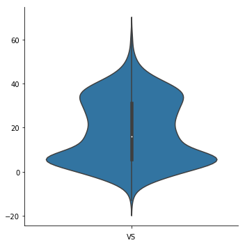

```python
display(df['VS'].describe().to_frame().to_html())

sns.catplot(x='VS', kind='violin', orient='v', data=df)
plt.show()
```

### High Value

X4HH had the highest VS (63.5) in a Jason Ness WinTF over Dom Demas.

```python
display(df[df['VS'] == df['VS'].max()].to_html())
```

[output not shown]

### Low Value

Match 9AOY* had the lowest VS (-13) in a LossTF Donald Mcneil fell to Wynn Michalak.

```python
display(df[df['VS'] == df['VS'].min()].to_html())
```

[output not shown]